# Intro Markdown

Alexander Palencia 20160391

7/30/2020

# Texto

## Italicas y Negritas

- La palabra **hola** está en negritas
  - utilizamos `**hola**`
- La palabra *mundo* está en cursiva
  - Utilizamos `*mundo*`

## Sub y Supra indices

- La formula quimica del agua es H<sub>2</sub>O y la del carbonato de sodio Na<sub>2</sub>CO<sub>3</sub>
  - H<sub>2</sub>O se logra poniendo: `H~2~O`
  - Na<sub>2</sub>CO<sub>3</sub> se logra poniendo: `Na~2~CO~3~`
- También se puede incluir texto:
  - Precio<sub>dia</sub>
- Podemos crear exponentes: X<sup>2</sup>
  - Eso se puede lograr asi: `X^2^`

## Inline Code

- Para asignar variables en R es `x <- y+1`
- Para que lo ejecute hacemos: 7
- El valor en la variable es 7

## Hipervinculos

- Para crear un link: `[Texto](url)`
  - Ejemplo: [Academatica](https://www.youtube.com/academatica)

## Imagenes

- Para agrgar imagenes: `![caption](URL/Direccion)`
  - Ejemplo:

[figure not shown]

## Imagenes con referencia

[figure not shown]

## Encabezados y Sub encabezados

- `# Heading 1`
- `## Heading 2`
- `### Heading 3`

## Listas

```
+ item 1
  + item 1.1
+ item 2
  + item 2.1
  + item 2.2
```

- item 1
  - item 1.1
- item 2
  - item 2.1
  - item 2.2

## Listas ordenadas

```
1. Item 1
  1. Item 1.1
  2. Item 1.2
2. Item 2
  + Item 2.1
```

1. Item 1
   1. Item 1.1
   2. Item 1.2
2. Item 2
   - Item 2.1

## Quotes

> “Keep away from people who try to belittle your ambitions. Small people always do that, but the really great make you feel that you, too, can become great.”

> — Mark Twain

## Plain Code Chunks

```
SELECT *
FROM table
  WHERE id > 100
  ORDER BY date
```

## Expresiones Matematicas

$\int_a^b e^{x^4}dx$

## Centradas:

$$\int_a^b e^{x^2}dx$$

```
$$X = \begin{bmatrix}1 & x_{1}\\
1 & x_{2}\\
1 & x_{3}
\end{bmatrix}$$
```

$$X = \begin{bmatrix}1 & x_{1}\\
1 & x_{2}\\
1 & x_{3}
\end{bmatrix}$$

```
$$\Theta = \begin{pmatrix}\alpha & \beta\\
\gamma & \delta
\end{pmatrix}$$
```

$$\Theta = \begin{pmatrix}\alpha & \beta\\
\gamma & \delta
\end{pmatrix}$$

Todas las ecuaciones se escriben usando Latex. Es de mucha utilidad este generador de latex.

[Generador de Latex](https://www.codecogs.com/latex/eqneditor.php)

### Python con r https://rstudio.github.io/reticulate/ ambiente en r y python.

### Usar un dataset de python pandas y usarlo con r. Instancia en AWS mysqlexamples-instance-1.coclu0fxxexm.us-east-1.rds.amazonaws.com yQ2znv

### Para conectarse a una base de datos se necesita instalar el driver Sde mySQL administrator de mySQL data https://db.rstudio.com/databases/my-sql/

```
##                      mpg cyl  disp  hp drat    wt  qsec vs am gear carb
## Mazda RX4           21.0   6 160.0 110 3.90 2.620 16.46  0  1    4    4
## Mazda RX4 Wag       21.0   6 160.0 110 3.90 2.875 17.02  0  1    4    4
## Datsun 710          22.8   4 108.0  93 3.85 2.320 18.61  1  1    4    1
## Hornet 4 Drive      21.4   6 258.0 110 3.08 3.215 19.44  1  0    3    1
## Hornet Sportabout   18.7   8 360.0 175 3.15 3.440 17.02  0  0    3    2
## Valiant             18.1   6 225.0 105 2.76 3.460 20.22  1  0    3    1
## Duster 360          14.3   8 360.0 245 3.21 3.570 15.84  0  0    3    4
## Merc 240D           24.4   4 146.7  62 3.69 3.190 20.00  1  0    4    2
## Merc 230            22.8   4 140.8  95 3.92 3.150 22.90  1  0    4    2
## Merc 280            19.2   6 167.6 123 3.92 3.440 18.30  1  0    4    4
## Merc 280C           17.8   6 167.6 123 3.92 3.440 18.90  1  0    4    4
## Merc 450SE          16.4   8 275.8 180 3.07 4.070 17.40  0  0    3    3
## Merc 450SL          17.3   8 275.8 180 3.07 3.730 17.60  0  0    3    3
## Merc 450SLC         15.2   8 275.8 180 3.07 3.780 18.00  0  0    3    3
## Cadillac Fleetwood  10.4   8 472.0 205 2.93 5.250 17.98  0  0    3    4
## Lincoln Continental 10.4   8 460.0 215 3.00 5.424 17.82  0  0    3    4
## Chrysler Imperial   14.7   8 440.0 230 3.23 5.345 17.42  0  0    3    4
## Fiat 128            32.4   4  78.7  66 4.08 2.200 19.47  1  1    4    1
## Honda Civic         30.4   4  75.7  52 4.93 1.615 18.52  1  1    4    2
## Toyota Corolla      33.9   4  71.1  65 4.22 1.835 19.90  1  1    4    1
## Toyota Corona       21.5   4 120.1  97 3.70 2.465 20.01  1  0    3    1
## Dodge Challenger    15.5   8 318.0 150 2.76 3.520 16.87  0  0    3    2
## AMC Javelin         15.2   8 304.0 150 3.15 3.435 17.30  0  0    3    2
## Camaro Z28          13.3   8 350.0 245 3.73 3.840 15.41  0  0    3    4
## Pontiac Firebird    19.2   8 400.0 175 3.08 3.845 17.05  0  0    3    2
## Fiat X1-9           27.3   4  79.0  66 4.08 1.935 18.90  1  1    4    1
## Porsche 914-2       26.0   4 120.3  91 4.43 2.140 16.70  0  1    5    2
## Lotus Europa        30.4   4  95.1 113 3.77 1.513 16.90  1  1    5    2
## Ford Pantera L      15.8   8 351.0 264 4.22 3.170 14.50  0  1    5    4
## Ferrari Dino        19.7   6 145.0 175 3.62 2.770 15.50  0  1    5    6
## Maserati Bora       15.0   8 301.0 335 3.54 3.570 14.60  0  1    5    8
## Volvo 142E          21.4   4 121.0 109 4.11 2.780 18.60  1  1    4    2
```

```r
library(dplyr)
df <-
mtcars %>%
  group_by(carb) %>%
  summarise(avg_mpg = mean(mpg))
```

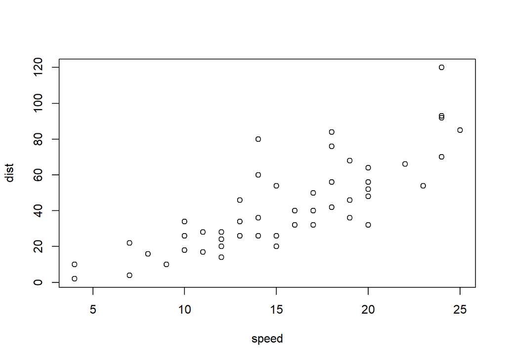

```r
plot(cars)
```

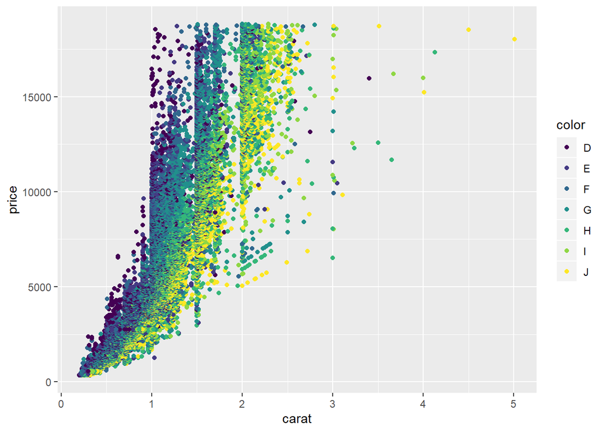

```r
library(ggplot2)
diamonds %>%
  ggplot(aes(carat, price, color=color))+
  geom_point()
```

```r
library(reticulate)
use_condaenv("r-reticulate")
```

```python
import pandas as pd

#iris_pandas = pd.read_csv(iris.txt)
#iris_pandas.head()
```

```r
library(RMySQL)
"
dbcon <- dbConnect(MySQL(),
                   host = 'mysqlexamples-instance-1.coclu0fxxexm.us-east-1.rds.amazonaws.com',
                   user = 'ufm_student',
                   password = 'yQ2znv',
                   dbname = 'datasets')

"
```

```
## [1] "\ndbcon <- dbConnect(MySQL(),\n                   host = 'mysqlexamples-instance-1.coclu0fxxexm.us-east-1.rds.amazonaws.com',\n                   user = 'ufm_student',\n                   password = 'yQ2znv',\n                   dbname = 'datasets')\n                   \n"
```

[output not shown]

[^1]: Imagen descargada de algun lado